# PraticalMachineLearning: Prediction Assignment Writeup

Barbara Mastrandrea

21/2/2017

# Introduction

Taking into account the data generated by the following study (http://groupware.les.inf.puc-rio.br/har) the purpose of the final project for the course Pratical Machine Learning is to verify if from the data produced by devices like Jawbone Up and Fitbit would be possible to understand whether the exercises were performed correctly.

In the course were highlighted the steps to follow to complete an analysis of this type and they are: question, data input, features, algorithm, parameters and evaluation; so I will follow this sequence, though not point by point, for my assignment.

### Question

According to the study afore mentioned: “Six young health participants were asked to perform one set of 10 repetitions of the Unilateral Dumbbell Biceps Curl in five different fashions: exactly according to the specification (Class A), throwing the elbows to the front (Class B), lifting the dumbbell only halfway (Class C), lowering the dumbbell only halfway (Class D) and throwing the hips to the front (Class E). Class A Corresponds to the specified execution of the exercise, while the other 4 classes Correspond to common mistakes.” Our goal is to predict the manner in which they did the exercise.

### Retrive and cleaning Data

So, first thing is to load all the required library and then retrive the data. The data for this project comes from this original source: http://groupware.les.inf.puc-rio.br/har.

```r
library(data.table)
library(mlbench)
library(caret)
library(klaR)
library(randomForest)
library(rattle)
```

```r
library(rpart)
library(rpart.plot)
```

The training data for this project are available here: https://d396qusza40orc.cloudfront.net/predmachlearn/pml-training.csv

The test data are available here: https://d396qusza40orc.cloudfront.net/predmachlearn/pml-testing.csv

I don’t need to download the data in my pc, I can load them to memory.

```r
TrainingData <- fread("https://d396qusza40orc.cloudfront.net/predmachlearn/pml-training.csv", header=T, na.strings=c("NA","#DIV/0!",""))
TestingData <- fread("http://d396qusza40orc.cloudfront.net/predmachlearn/pml-testing.csv", header=T, na.strings=c("NA","#DIV/0!",""))

dim(TrainingData)
```

```
## [1] 19622   160
```

```r
dim(TestingData)
```

```
## [1]  20 160
```

Now, I give a look at the data using the commands “summary(Training Date)” and “str(Training Date)” and, since I have 160 columns, I extract the names of the columns. I don’t include the output of “summary” and “str” because these commands extract a lot of rows but I think that the list of the names is important to know.

```r
names(TrainingData)
```

```
##   [1] "V1"                       "user_name"
##   [3] "raw_timestamp_part_1"     "raw_timestamp_part_2"
##   [5] "cvtd_timestamp"           "new_window"
##   [7] "num_window"               "roll_belt"
##   [9] "pitch_belt"               "yaw_belt"
##  [11] "total_accel_belt"         "kurtosis_roll_belt"
##  [13] "kurtosis_picth_belt"      "kurtosis_yaw_belt"
##  [15] "skewness_roll_belt"       "skewness_roll_belt.1"
##  [17] "skewness_yaw_belt"        "max_roll_belt"
##  [19] "max_picth_belt"           "max_yaw_belt"
##  [21] "min_roll_belt"            "min_pitch_belt"
##  [23] "min_yaw_belt"             "amplitude_roll_belt"
##  [25] "amplitude_pitch_belt"     "amplitude_yaw_belt"
##  [27] "var_total_accel_belt"     "avg_roll_belt"
##  [29] "stddev_roll_belt"         "var_roll_belt"
```

[output cut: 65 more lines]

So I have several columns with the values “NA”, and also many columns contain measures that do not interest me at this time (I want the variables for belt, arm and forearm). So the next step is to create a subset of data with measurements that interest me and wirh the addition of the column “result”. The first thing to do is use “sapply” on the TrainingData and retrive all variable with NA or blank then use the list to subset the main set of data.

```r
List_Na <- sapply(TrainingData, function (x) any(is.na(x)))
newTrainingData <- subset(TrainingData, select=c("classe", names(List_Na)[!List_Na & grepl("belt|[^(fore)]arm|dumbbell|forearm", names(List_Na))]))
```

Then, I have to convert classe to a Factor data type, so that caret builds a classification instead of a regression model.

```r
newTrainingData <- newTrainingData[, classe := factor(newTrainingData[, classe])]
newTrainingData[, .N, classe]
```

```
##    classe    N
## 1:      A 5580
## 2:      B 3797
## 3:      C 3422
## 4:      D 3216
## 5:      E 3607
```

Last thing to do is split the training dato in two batch, a 60% training data and a 40% testing data.

```r
inTrain <- createDataPartition(newTrainingData$classe, p=0.6, list=FALSE)
Train_data <- newTrainingData[inTrain, ]
Test_data <- newTrainingData[-inTrain, ]
```

Then I check if in my batch there are near-zero variance predictors

```r
nzv <- nearZeroVar(Train_data, saveMetrics=TRUE)
nzv
```

```
##                      freqRatio percentUnique zeroVar   nzv
## classe                1.469065    0.04245924   FALSE FALSE
## roll_belt             1.088512    8.72961957   FALSE FALSE
## pitch_belt            1.026087   13.73131793   FALSE FALSE
## yaw_belt              1.012422   14.54653533   FALSE FALSE
## total_accel_belt      1.047049    0.22927989   FALSE FALSE
## gyros_belt_x          1.083130    1.02751359   FALSE FALSE
## gyros_belt_y          1.140681    0.54347826   FALSE FALSE
## gyros_belt_z          1.087584    1.37567935   FALSE FALSE
## accel_belt_x          1.002088    1.31623641   FALSE FALSE
## accel_belt_y          1.093478    1.15489130   FALSE FALSE
## accel_belt_z          1.070524    2.42866848   FALSE FALSE
## magnet_belt_x         1.113208    2.47112772   FALSE FALSE
## magnet_belt_y         1.100775    2.42866848   FALSE FALSE
## magnet_belt_z         1.021583    3.63451087   FALSE FALSE
## roll_arm             52.000000   19.48879076   FALSE FALSE
## pitch_arm            75.111111   22.53736413   FALSE FALSE
## yaw_arm              31.200000   21.37398098   FALSE FALSE
## total_accel_arm       1.000000    0.56046196   FALSE FALSE
## gyros_arm_x           1.049342    5.26494565   FALSE FALSE
## gyros_arm_y           1.525084    3.08254076   FALSE FALSE
## gyros_arm_z           1.140127    1.97010870   FALSE FALSE
## accel_arm_x           1.009346    6.42832880   FALSE FALSE
## accel_arm_y           1.102190    4.41576087   FALSE FALSE
## accel_arm_z           1.024390    6.47078804   FALSE FALSE
## magnet_arm_x          1.075472   11.14979620   FALSE FALSE
## magnet_arm_y          1.120690    7.18410326   FALSE FALSE
## magnet_arm_z          1.000000   10.52139946   FALSE FALSE
## roll_dumbbell         1.094595   87.48301630   FALSE FALSE
## pitch_dumbbell        2.469136   85.30910326   FALSE FALSE
## yaw_dumbbell          1.051948   86.82065217   FALSE FALSE
## total_accel_dumbbell  1.096459    0.33967391   FALSE FALSE
## gyros_dumbbell_x      1.005450    1.95312500   FALSE FALSE
## gyros_dumbbell_y      1.222222    2.25033967   FALSE FALSE
## gyros_dumbbell_z      1.062842    1.61345109   FALSE FALSE
## accel_dumbbell_x      1.005000    3.39673913   FALSE FALSE
## accel_dumbbell_y      1.025641    3.83831522   FALSE FALSE
## accel_dumbbell_z      1.220690    3.31182065   FALSE FALSE
## magnet_dumbbell_x     1.066667    8.86548913   FALSE FALSE
## magnet_dumbbell_y     1.137615    6.92934783   FALSE FALSE
## magnet_dumbbell_z     1.180952    5.54517663   FALSE FALSE
## roll_forearm         12.296875   14.87771739   FALSE FALSE
## pitch_forearm        67.428571   20.90692935   FALSE FALSE
## yaw_forearm          14.658385   14.17289402   FALSE FALSE
## total_accel_forearm   1.127199    0.56895380   FALSE FALSE
## gyros_forearm_x       1.033951    2.33525815   FALSE FALSE
## gyros_forearm_y       1.051948    6.07167120   FALSE FALSE
## gyros_forearm_z       1.122807    2.39470109   FALSE FALSE
## accel_forearm_x       1.070175    6.53872283   FALSE FALSE
## accel_forearm_y       1.100000    8.09273098   FALSE FALSE
## accel_forearm_z       1.044444    4.61107337   FALSE FALSE
## magnet_forearm_x      1.020408   12.06691576   FALSE FALSE
## magnet_forearm_y      1.333333   15.34476902   FALSE FALSE
## magnet_forearm_z      1.078947   13.44259511   FALSE FALSE
```

I don’t have any predictors with near-zero variance so I can proceed with building my model.

### Building Model

To fit a model to the data I use the function “train” and a partial least squares discriminant analysis (PLSDA) model to start.

```r
set.seed(12345)
ctrl <- trainControl(method = "repeatedcv", repeats = 3, classProbs = TRUE, summaryFunction = defaultSummary)
plsFit <- train(classe ~ ., data = Train_data, method = "pls", tuneLength = 15, trControl = ctrl, metric = "ROC", preProc = c("center","scale"))
plsFit
```

```
## Partial Least Squares
##
## 11776 samples
##    52 predictor
##     5 classes: 'A', 'B', 'C', 'D', 'E'
##
## Pre-processing: centered (52), scaled (52)
## Resampling: Cross-Validated (10 fold, repeated 3 times)
## Summary of sample sizes: 10598, 10599, 10600, 10599, 10598, 10599, ...
## Resampling results across tuning parameters:
##
##   ncomp  Accuracy   Kappa
##    1     0.3318887  0.1164456
##    2     0.3488998  0.1426214
##    3     0.3847946  0.2026786
##    4     0.4542298  0.2956477
##    5     0.4881668  0.3415637
##    6     0.5002823  0.3579314
##    7     0.5185408  0.3811274
##    8     0.5385246  0.4084356
##    9     0.5538372  0.4290431
##   10     0.5730576  0.4539975
##   11     0.5813205  0.4650912
##   12     0.5844903  0.4693567
##   13     0.6013618  0.4906824
##   14     0.6071929  0.4981147
##   15     0.6118051  0.5038503
##
## Accuracy was used to select the optimal model using  the largest value.
## The final value used for the model was ncomp = 15.
```

In this output the grid of results are the average resampled estimates of performance. Then I use “predict” to apply the model on my test data.

```r
plsClasses <- predict(plsFit, newdata = Test_data)
str(plsClasses)
```

```
##  Factor w/ 5 levels "A","B","C","D",..: 1 1 1 1 1 1 1 1 1 1 ...
```

I can also calculate this using the option type = “prob” to compute class probabilities from the model.

```r
plsProbs <- predict(plsFit, newdata = Test_data, type = "prob")
head(plsProbs)
```

```
##           A         B         C         D         E
## 1 0.4161902 0.1279336 0.1588315 0.1301685 0.1668762
## 2 0.4109726 0.1276606 0.1595853 0.1309663 0.1708152
## 3 0.4226849 0.1260611 0.1567196 0.1289634 0.1655711
## 4 0.4188902 0.1264487 0.1564826 0.1286400 0.1695385
## 5 0.4134707 0.1253492 0.1569887 0.1297661 0.1744253
## 6 0.4144856 0.1250115 0.1573009 0.1306059 0.1725961
```

I use a plot to display the result in a best manner.

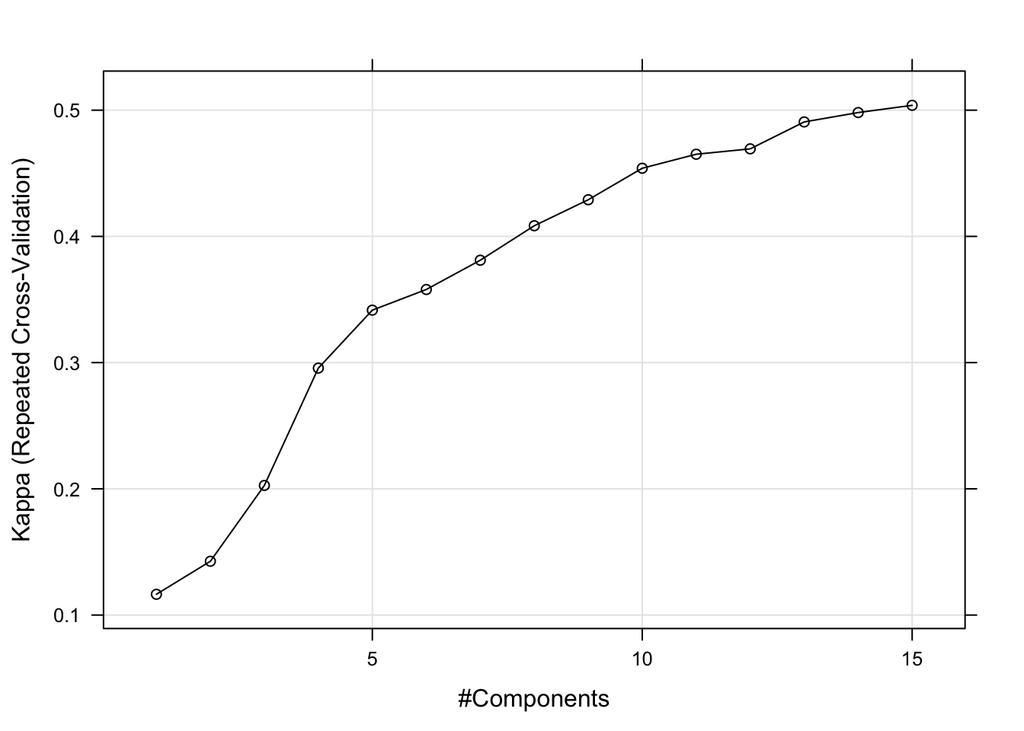

```r
trellis.par.set(caretTheme())
plot(plsFit, metric = "Kappa")
```

```r
confusionMatrix(plsClasses, Test_data$classe)
```

```
## Confusion Matrix and Statistics
##
##           Reference
## Prediction    A    B    C    D    E
##          A 1863  449  317  157  131
##          B   56  651   79   79  191
##          C  104  180  699  113  134
##          D  181   82  203  818  168
##          E   28  156   70  119  818
##
## Overall Statistics
##
##                Accuracy : 0.618
##                  95% CI : (0.6072, 0.6288)
##     No Information Rate : 0.2845
##     P-Value [Acc > NIR] : < 2.2e-16
##
##                   Kappa : 0.5119
##  Mcnemar's Test P-Value : < 2.2e-16
##
## Statistics by Class:
##
##                      Class: A Class: B Class: C Class: D Class: E
## Sensitivity            0.8347  0.42885  0.51096   0.6361   0.5673
## Specificity            0.8123  0.93600  0.91803   0.9034   0.9418
## Pos Pred Value         0.6387  0.61648  0.56829   0.5634   0.6868
## Neg Pred Value         0.9251  0.87231  0.89888   0.9268   0.9062
## Prevalence             0.2845  0.19347  0.17436   0.1639   0.1838
## Detection Rate         0.2374  0.08297  0.08909   0.1043   0.1043
## Detection Prevalence   0.3718  0.13459  0.15677   0.1851   0.1518
## Balanced Accuracy      0.8235  0.68243  0.71450   0.7697   0.7545
```

I can apply another model like the “regularized discriminant analysis” model

```r
set.seed(123)
rdaFit <- train(classe ~ ., data = Train_data, method = "rda", tuneGrid = data.frame(gamma = (0:4)/4, lambda = 3/4), trControl = ctrl, metric = "ROC")
rdaFit
```

```
## Regularized Discriminant Analysis
##
## 11776 samples
##    52 predictor
##     5 classes: 'A', 'B', 'C', 'D', 'E'
##
## No pre-processing
## Resampling: Cross-Validated (10 fold, repeated 3 times)
## Summary of sample sizes: 10599, 10599, 10598, 10598, 10599, 10598, ...
## Resampling results across tuning parameters:
##
##   gamma  Accuracy   Kappa
##   0.00   0.8380605  0.7955359
##   0.25   0.5855122  0.4773392
##   0.50   0.5215123  0.3955448
##   0.75   0.4774375  0.3389564
##   1.00   0.3967091  0.2326221
##
## Tuning parameter 'lambda' was held constant at a value of 0.75
## Accuracy was used to select the optimal model using  the largest value.
## The final values used for the model were gamma = 0 and lambda = 0.75.
```

```r
rdaClasses <- predict(rdaFit, newdata = Test_data)
confusionMatrix(rdaClasses, Test_data$classe)
```

```
## Confusion Matrix and Statistics
##
##           Reference
## Prediction    A    B    C    D    E
##          A 1949  173   26    7   13
##          B   27 1109   77    3   70
##          C  127  194 1240  204   88
##          D  121   32   22 1058   85
##          E    8   10    3   14 1186
##
## Overall Statistics
##
##                Accuracy : 0.8338
##                  95% CI : (0.8254, 0.842)
##     No Information Rate : 0.2845
##     P-Value [Acc > NIR] : < 2.2e-16
##
##                   Kappa : 0.7903
##  Mcnemar's Test P-Value : < 2.2e-16
##
## Statistics by Class:
##
##                      Class: A Class: B Class: C Class: D Class: E
## Sensitivity            0.8732   0.7306   0.9064   0.8227   0.8225
## Specificity            0.9610   0.9720   0.9054   0.9604   0.9945
## Pos Pred Value         0.8990   0.8624   0.6692   0.8027   0.9713
## Neg Pred Value         0.9502   0.9377   0.9786   0.9651   0.9614
## Prevalence             0.2845   0.1935   0.1744   0.1639   0.1838
## Detection Rate         0.2484   0.1413   0.1580   0.1348   0.1512
## Detection Prevalence   0.2763   0.1639   0.2362   0.1680   0.1556
## Balanced Accuracy      0.9171   0.8513   0.9059   0.8915   0.9085
```

and see how these two models (pls, rda) compare in terms of their resampling results.

```r
resamps <- resamples(list(pls = plsFit, rda = rdaFit))
summary(resamps)
```

```
##
## Call:
## summary.resamples(object = resamps)
##
## Models: pls, rda
## Number of resamples: 30
##
## Accuracy
##       Min. 1st Qu. Median   Mean 3rd Qu.   Max. NA's
## pls 0.5944  0.6024 0.6105 0.6118  0.6193 0.6333    0
## rda 0.8132  0.8297 0.8390 0.8381  0.8470 0.8547    0
##
## Kappa
##       Min. 1st Qu. Median   Mean 3rd Qu.   Max. NA's
## pls 0.4807  0.4926 0.5020 0.5039  0.5133 0.5323    0
## rda 0.7642  0.7850 0.7967 0.7955  0.8069 0.8164    0
```

```r
diffs <- diff(resamps)
summary(diffs)
```

```
##
## Call:
## summary.diff.resamples(object = diffs)
##
## p-value adjustment: bonferroni
## Upper diagonal: estimates of the difference
## Lower diagonal: p-value for H0: difference = 0
##
## Accuracy
##     pls       rda
## pls           -0.2263
## rda < 2.2e-16
##
## Kappa
##     pls       rda
## pls           -0.2917
## rda < 2.2e-16
```

And then a plot to visualise the result

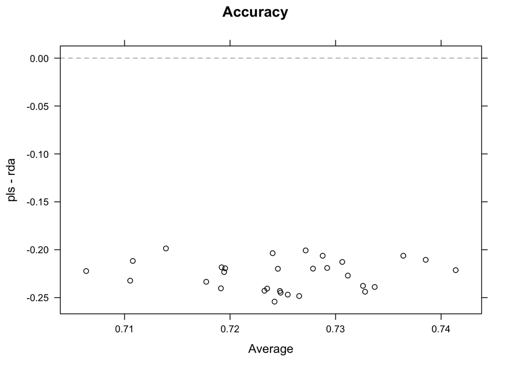

```r
xyplot(resamps, what = "BlandAltman")
```

I can now also try the “Random Forest” model:

```r
rfFit <- train(classe~., data=Train_data, method="rf", tuneGrid=expand.grid(.mtry=sqrt(ncol(Train_data[,2:53]))), trControl=ctrl)
rfFit
```

```
## Random Forest
##
## 11776 samples
##    52 predictor
##     5 classes: 'A', 'B', 'C', 'D', 'E'
##
## No pre-processing
## Resampling: Cross-Validated (10 fold, repeated 3 times)
## Summary of sample sizes: 10599, 10600, 10598, 10597, 10597, 10599, ...
## Resampling results:
##
##   Accuracy   Kappa
##   0.9928104  0.9909055
##
## Tuning parameter 'mtry' was held constant at a value of 7.211103
##
```

```r
rfClasses <- predict(rfFit, newdata = Test_data)
confusionMatrix(rfClasses, Test_data$classe)
```

```
## Confusion Matrix and Statistics
##
##           Reference
## Prediction    A    B    C    D    E
##          A 2230    6    0    0    0
##          B    0 1508    7    0    0
##          C    1    4 1355   28    0
##          D    0    0    6 1258    6
##          E    1    0    0    0 1436
##
## Overall Statistics
##
##                Accuracy : 0.9925
##                  95% CI : (0.9903, 0.9943)
##     No Information Rate : 0.2845
##     P-Value [Acc > NIR] : < 2.2e-16
##
##                   Kappa : 0.9905
##  Mcnemar's Test P-Value : NA
##
## Statistics by Class:
##
##                      Class: A Class: B Class: C Class: D Class: E
## Sensitivity            0.9991   0.9934   0.9905   0.9782   0.9958
## Specificity            0.9989   0.9989   0.9949   0.9982   0.9998
## Pos Pred Value         0.9973   0.9954   0.9762   0.9906   0.9993
## Neg Pred Value         0.9996   0.9984   0.9980   0.9957   0.9991
## Prevalence             0.2845   0.1935   0.1744   0.1639   0.1838
## Detection Rate         0.2842   0.1922   0.1727   0.1603   0.1830
## Detection Prevalence   0.2850   0.1931   0.1769   0.1619   0.1832
## Balanced Accuracy      0.9990   0.9962   0.9927   0.9882   0.9978
```

```r
varImp(rfFit)
```

```
## rf variable importance
##
##   only 20 most important variables shown (out of 52)
##
##                      Overall
## roll_belt             100.00
## yaw_belt               70.26
## pitch_forearm          61.84
## magnet_dumbbell_z      58.72
## pitch_belt             53.55
## magnet_dumbbell_y      52.05
## roll_forearm           48.53
## magnet_dumbbell_x      36.36
## roll_dumbbell          32.71
## accel_dumbbell_y       30.76
## accel_belt_z           30.19
## magnet_belt_y          28.91
## magnet_belt_z          28.71
## accel_dumbbell_z       25.75
## roll_arm               23.20
## accel_forearm_x        22.53
## gyros_belt_z           21.14
## magnet_forearm_z       20.51
## total_accel_dumbbell   19.14
## gyros_dumbbell_y       18.78
```

```r
rfFit$finalModel
```

```
##
## Call:
##  randomForest(x = x, y = y, mtry = param$mtry)
##                Type of random forest: classification
##                      Number of trees: 500
## No. of variables tried at each split: 7
##
##         OOB estimate of  error rate: 0.7%
## Confusion matrix:
##      A    B    C    D    E class.error
## A 3343    5    0    0    0 0.001493429
## B   13 2256   10    0    0 0.010092146
## C    0   10 2039    4    1 0.007302824
## D    0    0   27 1900    3 0.015544041
## E    0    0    1    8 2156 0.004157044
```

## Conclusion

Now I can try to use this model on my original tasting batch of data and so:

```r
TestResult <- predict(rfFit, newdata=TestingData)
TestResult
```

```
##  [1] B A B A A E D B A A B C B A E E A B B B
## Levels: A B C D E
```